# PhyloGLM analysis

Bin He

2022-08-18 (updated: 2022-08-20)

```r
suppressPackageStartupMessages(require(tidyverse))
suppressPackageStartupMessages(require(cowplot))
suppressPackageStartupMessages(require(phytools))
suppressPackageStartupMessages(require(phylolm))
```

## Introduction

*Goal*

- Test the hypothesis that pathogenic Candida lineages have a larger Hil family, while controlling for phylogenetic relatedness

*Input*

- Species tree
- Gene family size vector

*Approach*

- t-test under the incorrect assumption of independence among the Hil family size values across species (they are related by the tree and thus are not i.i.d.)
- PhyloGLM using the `phylolm` package in R, which tests for association between a quantitative independent variable (Hil family size) and a binary dependent variable (pathogen or not)

## Analysis

### Load data

Species tree

```r
spsInfo <- read_tsv("../input/20220518-expanded-blast-species-info.tsv", col_types = cols())
tree <- read.tree("../input/20220521-generax-species-tree.nwk")
```

Encode the life history trait

```r
trait <- spsInfo %>%
  mutate(species = treeName,
         pathogen = fct_recode(pathogen, Yes = "human", Yes = "crustacean", No = "human (rare)", No = "no report"),
         .keep = "none")
```

Gene family size

```r
famSize <- read_tsv("../input/20220818-Hil-family-size-adhesin-status-summary.tsv", col_types = cols()) %>%
  mutate(species = factor(gsub(" ", "_", species), levels = tree$tip.label)) %>%
  group_by(species) %>%
  summarize(total = n(), FRV = sum(frv.pred), SP = sum(sp.pred), GPI = sum(gpi.pred),
            final = sum(frv.pred & sp.pred & gpi.pred)) %>%
  select(species, total, final) %>%
  # complete missing values for S. cerevisiae
  complete(species, fill = list(total = 0, final = 0))
```

### Visually compare the pathogen vs non-pathogens

```r
dat <- left_join(trait, famSize, by = "species") %>%
  column_to_rownames(var = "species")
```

We remove *M. bicuspidata* here as it doesn’t fit either the human pathogen or the low pathogenic potential group.

```r
dat1 <- dat %>%
  filter(species != "Metschnikowia_bicuspidata")
```

Plot as boxplots

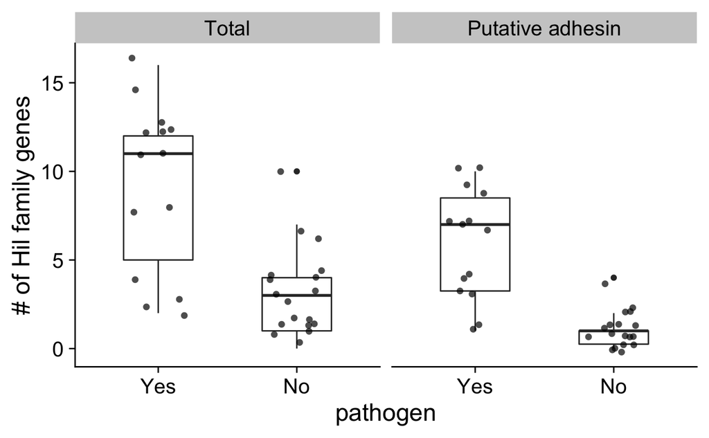

```r
p <- dat1 %>%
  pivot_longer(c(total, final), names_to = "var", values_to = "n") %>%
  mutate(var = fct_recode(var, Total = "total", `Putative adhesin` = "final") %>%
           fct_relevel("Total")) %>%
  ggplot(aes(x = pathogen, y = n)) +
  geom_boxplot(width = 0.5) +
  geom_jitter(width = 0.2, alpha = 0.7, size = 2, shape = 16) +
  ylab("# of Hil family genes")
p + facet_wrap(~var) + theme_cowplot(font_size = 18)
ggsave(file = "../output/img/20220819-Hil-family-size-between-PA-nonPA.png",
       plot = p + facet_wrap(~var, nrow = 2) + theme_bw(base_size = 12) + background_grid(major = "y"),
       width = 3, height = 4)
```

### Star phylogeny test

Here we make the incorrect assumption that all species are equally related to each other, such that both their traits and their family sizes evolved independently from the common ancestor. We are looking to test whether there is an association between the life history trait and the Hil family size

1. t-test for total number of Hil family homologs

```r
t.test(total ~ pathogen, data = dat1, alternative = "greater")
```

```
    Welch Two Sample t-test

data:  total by pathogen
t = 4.2947, df = 18.603, p-value = 0.000204
alternative hypothesis: true difference in means between group Yes and group No is greater than 0
95 percent confidence interval:
 3.610066      Inf
sample estimates:
mean in group Yes  mean in group No
         9.214286          3.166667
```

1. t-test for putative adhesins within the Hil family

```r
t.test(final ~ pathogen, data = dat1, alternative = "greater")
```

```
    Welch Two Sample t-test

data:  final by pathogen
t = 5.4787, df = 15.029, p-value = 3.155e-05
alternative hypothesis: true difference in means between group Yes and group No is greater than 0
95 percent confidence interval:
 3.265397      Inf
sample estimates:
mean in group Yes  mean in group No
         5.857143          1.055556
```

1. non-parametric rank sum test for total number of Hil family homologs

```r
wilcox.test(total ~ pathogen, data = dat1, paired = FALSE, alternative = "greater")
```

```
    Wilcoxon rank sum test with continuity correction

data:  total by pathogen
W = 214.5, p-value = 0.0003852
alternative hypothesis: true location shift is greater than 0
```

1. non-parametric rank sum test for putative adhesins within the Hil family

```r
wilcox.test(final ~ pathogen, data = dat1, paired = FALSE, alternative = "greater")
```

```
    Wilcoxon rank sum test with continuity correction

data:  final by pathogen
W = 232, p-value = 2.004e-05
alternative hypothesis: true location shift is greater than 0
```

### Phylogenetic regression using PhyloGLM

Prepare data

```r
df <- dat %>% column_to_rownames(var = "species") %>%
  mutate(pathogen = 2 - as.numeric(pathogen))
df1 <- dat1 %>% column_to_rownames(var = "species") %>%
  mutate(pathogen = 2 - as.numeric(pathogen))
```

1. Fit the model with *M. bicuspidata* included, using the total number of Hil family homologs as the independent variable

```r
fit = list()
fit$'all.total' <- phyloglm(formula = pathogen ~ total, data = df, phy = tree, method = "logistic_IG10", btol = 50, boot = 100)
summary(fit$"all.total")
```

```
Call:
phyloglm(formula = pathogen ~ total, data = df, phy = tree, method = "logistic_IG10",
    btol = 50, boot = 100)
       AIC     logLik Pen.logLik
     34.21     -14.10     -11.20

Method: logistic_IG10
Mean tip height: 1.157805
Parameter estimate(s):
alpha: 6.551881
      bootstrap mean: 0 (on log scale, then back transformed)
      so possible downward bias.
      bootstrap 95% CI: (0,46.88077)

Coefficients:
            Estimate   StdErr  z.value lowerbootCI upperbootCI  p.value
(Intercept) -2.25174  0.79457 -2.83391    -2.88800      0.0000 0.004598 **
total        0.33309  0.11817  2.81863     0.00000      0.4041 0.004823 **
---
Signif. codes:  0 ‘***’ 0.001 ‘**’ 0.01 ‘*’ 0.05 ‘.’ 0.1 ‘ ’ 1

Note: Wald-type p-values for coefficients, conditional on alpha=6.551881
      Parametric bootstrap results based on 100 fitted replicates
```

1. Fit the model with *M. bicuspidata* included, using the number of putative adhesins in the Hil family as the independent variable

```r
fit$'all.final' <- phyloglm(formula = pathogen ~ final, data = df, phy = tree, method = "logistic_IG10", btol = 50, boot = 100)
summary(fit$'all.final')
```

```
Call:
phyloglm(formula = pathogen ~ final, data = df, phy = tree, method = "logistic_IG10",
    btol = 50, boot = 100)
       AIC     logLik Pen.logLik
     31.29     -12.65     -10.53

Method: logistic_IG10
Mean tip height: 1.157805
Parameter estimate(s):
alpha: 7.882776
      bootstrap mean: 4.333247 (on log scale, then back transformed)
      so possible downward bias.
      bootstrap 95% CI: (0.01593853,47.12054)

Coefficients:
            Estimate   StdErr  z.value lowerbootCI upperbootCI  p.value
(Intercept) -2.00794  0.70630 -2.84289    -3.28733     -0.8519 0.004471 **
final        0.66937  0.24970  2.68068     0.36803      1.3717 0.007347 **
---
Signif. codes:  0 ‘***’ 0.001 ‘**’ 0.01 ‘*’ 0.05 ‘.’ 0.1 ‘ ’ 1

Note: Wald-type p-values for coefficients, conditional on alpha=7.882776
      Parametric bootstrap results based on 100 fitted replicates
```

1. Fit the model without *M. bicuspidata*, using the total number of Hil family homologs as the independent variable

```r
tree1 <- drop.tip(phy = tree, tip = "Metschnikowia_bicuspidata")
fit$'noM.total' <- phyloglm(formula = pathogen ~ total, data = df1, phy = tree1, method = "logistic_IG10", btol = 50, boot = 100)
summary(fit$"noM.total")
```

```
Call:
phyloglm(formula = pathogen ~ total, data = df1, phy = tree1,
    method = "logistic_IG10", btol = 50, boot = 100)
       AIC     logLik Pen.logLik
     34.23     -14.12     -11.22

Method: logistic_IG10
Mean tip height: 1.15485
Parameter estimate(s):
alpha: 7.046933
      bootstrap mean: 6.934126 (on log scale, then back transformed)
      so possible downward bias.
      bootstrap 95% CI: (0.01868179,47.14353)

Coefficients:
            Estimate   StdErr  z.value lowerbootCI upperbootCI  p.value
(Intercept) -2.26992  0.79867 -2.84214    -3.84533     -1.1119 0.004481 **
total        0.33745  0.11921  2.83062     0.15325      0.6320 0.004646 **
---
Signif. codes:  0 ‘***’ 0.001 ‘**’ 0.01 ‘*’ 0.05 ‘.’ 0.1 ‘ ’ 1

Note: Wald-type p-values for coefficients, conditional on alpha=7.046933
      Parametric bootstrap results based on 100 fitted replicates
```

1. Fit the model without *M. bicuspidata*, using the number of putative adhesins in the Hil family as the independent variable

```r
fit$'noM.final' <- phyloglm(formula = pathogen ~ final, data = df1, phy = tree1, method = "logistic_IG10", btol = 50, boot = 100)
summary(fit$'noM.final')
```

```
Call:
phyloglm(formula = pathogen ~ final, data = df1, phy = tree1,
    method = "logistic_IG10", btol = 50, boot = 100)
       AIC     logLik Pen.logLik
    25.830     -9.915     -8.155

Method: logistic_IG10
Mean tip height: 1.15485
Parameter estimate(s):
alpha: 7.27512
      bootstrap mean: 4.245914 (on log scale, then back transformed)
      so possible downward bias.
      bootstrap 95% CI: (0.01588702,47.0338)

Coefficients:
            Estimate   StdErr  z.value lowerbootCI upperbootCI  p.value
(Intercept) -2.59321  0.87054 -2.97887    -3.76900     -1.0333 0.002893 **
final        0.84599  0.31887  2.65307     0.32816      1.8565 0.007976 **
---
Signif. codes:  0 ‘***’ 0.001 ‘**’ 0.01 ‘*’ 0.05 ‘.’ 0.1 ‘ ’ 1

Note: Wald-type p-values for coefficients, conditional on alpha=7.27512
      Parametric bootstrap results based on 100 fitted replicates
```